# TP Mongo - correction

DU ABD

Correction de ce [TP](https://fxjollois.github.io/cours-2020-2021/du-abd/du-abd--r-mongodb)

```r
library(mongolite)
library(ggplot2)
library(dplyr)
```

## Restaurants

On reprend les instructions de connexion vues dans le TP. Pour les adapter au cas où vous avez installé MongoDB en local sur votre ordinateur, il suffit de ne garder que la dernière instruction (`m = mongo(...)`), en supprimant le paramètre `url = URI`.

```r
USER = "user"
PASS = "user"
HOST = "cluster0.ougec.mongodb.net"
URI = sprintf("mongodb+srv://%s:%s@%s/", USER, PASS, HOST)

m = mongo(
  collection = "restaurants",
  db = "sample_restaurants",
  url = URI)
```

### Lister tous les restaurants de la chaîne “Bareburger” (rue, quartier)

Restriction sur le nom + projection sur certains champs

```r
m$find(
  query = '{ "name": "Bareburger" }',
  fields = '{ "_id": 0, "address.street": 1, "borough": 1 }'
)
```

```
##              street   borough
## 1         31 Avenue    Queens
## 2   Laguardia Place Manhattan
## 3          7 Avenue  Brooklyn
## 4          8 Avenue Manhattan
## 5         31 Street    Queens
## 6          2 Avenue Manhattan
## 7     Austin Street    Queens
## 8    Bell Boulevard    Queens
## 9          Court St  Brooklyn
## 10 West   46 Street Manhattan
## 11         1 Avenue Manhattan
## 12       William St Manhattan
```

### Lister les trois chaînes de restaurant les plus présentes

2 possibilités ici, avec un résultat bien évidemment identique :

- avec `$group` + `$sort`

```r
m$aggregate(
  '[
  { "$group": {"_id": "$name", "nb": { "$sum": 1 }}},
  { "$sort": { "nb": -1 }},
  { "$limit": 3 }
  ]'
)
```

```
##                _id  nb
## 1           Subway 421
## 2 Starbucks Coffee 223
## 3       Mcdonald'S 208
```

- directement avec `$sortByCount`

```r
m$aggregate(
  '[
  { "$sortByCount": "$name" },
  { "$limit": 3 }
  ]')
```

```
##                _id count
## 1           Subway   421
## 2 Starbucks Coffee   223
## 3       Mcdonald'S   208
```

### Donner les 10 styles de cuisine les plus présents dans la collection

Similaire à la question précédente

```r
m$aggregate(
  '[
  { "$sortByCount": "$cuisine" },
  { "$limit": 10 }
  ]')
```

```
##                                                                 _id count
## 1                                                          American  6183
## 2                                                           Chinese  2418
## 3                                                   Café/Coffee/Tea  1214
## 4                                                             Pizza  1163
## 5                                                           Italian  1069
## 6                                                             Other  1011
## 7  Latin (Cuban, Dominican, Puerto Rican, South & Central American)   850
## 8                                                          Japanese   760
## 9                                                           Mexican   754
## 10                                                           Bakery   691
```

### Lister les 10 restaurants les moins bien notés (note moyenne la plus haute)

Ici, on doit déjà *dérouler* ou *exploser* le tableau des visites, puis ensuite calculer la note moyenne par restaurant

```r
m$aggregate(
  '[
  { "$unwind": "$grades" },
  { "$group": {
    "_id": { "id": "$restaurant_id", "name": "$name" },
    "noteMoyenne": { "$avg": "$grades.score" }
  }},
  { "$sort": { "noteMoyenne": -1 }},
  { "$limit": 10 }
  ]'
)
```

```
##      _id.id                _id.name noteMoyenne
## 1  50015959     Juice It Health Bar          75
## 2  50017374   Golden Dragon Cuisine          73
## 3  50015245     Palombo Pastry Shop          69
## 4  50018457 Chelsea'S Juice Factory          69
## 5  41703965             Go Go Curry          65
## 6  50017252      K & D Internet Inc          61
## 7  50011285                   Koyla          61
## 8  50013507        Ivory D O S  Inc          60
## 9  50011359               Aki Sushi          60
## 10 50018376     Ab Halal Restaurant          58
```

### Lister par quartier le nombre de restaurants, le score moyen et le pourcentage moyen d’évaluation A

Il faut calculer par restaurants le score moyen + le nombre d’évaluation (global et uniquement de A), tout en gardant le quartier comme information. Ensuite, on calcule par restaurant le pourcentage d’évaluation A. Et enfin, on refait un `$group` par quartier pour finir.

```r
m$aggregate(
  '[
  { "$unwind": "$grades" },
  { "$group": {
    "_id": { "id": "$restaurant_id", "q": "$borough" },
    "scoreMoyen": { "$avg": "$grades.score" },
    "nbEvals": { "$sum": 1 },
    "nbA": { "$sum": { "$cond": [ { "$eq": ["$grades.grade", "A"] }, 1, 0 ] }}
  }},
  { "$addFields": { "pctA": { "$divide": [ "$nbA", "$nbEvals" ]}}},
  { "$group": {
    "_id": "$_id.q",
    "nbRestaurants": { "$sum": 1 },
    "scoreMoyen": { "$avg": "$scoreMoyen" },
    "pctMoyenA": { "$avg": "$pctA" }
  }}
  ]'
)
```

```
##             _id nbRestaurants scoreMoyen pctMoyenA
## 1       Missing            50    9.38000 0.9600000
## 2      Brooklyn          5894   11.09892 0.8016624
## 3        Queens          5482   11.34453 0.7917618
## 4     Manhattan          9987   11.06553 0.8194063
## 5         Bronx          2273   10.87371 0.8146644
## 6 Staten Island           935   11.18433 0.8082926
```

## AirBnB

### Créer la connexion à la collection dans R

```r
USER = "user"
PASS = "user"
HOST = "cluster0.ougec.mongodb.net"
URI = sprintf("mongodb+srv://%s:%s@%s/", USER, PASS, HOST)

data = mongo(
  collection = "listingsAndReviews",
  db = "sample_airbnb",
  url = URI
)
```

### Donner le nombre de logements

```r
data$count()
```

```
## [1] 5555
```

### Lister les informations du logement “10545725” (cf _id)

```r
df = data$find(query = '{"_id": "10545725"}')
# Pour l'afficher plus "joliment"
jsonlite::toJSON(as.list(df), pretty = T, auto_unbox = T)
```

```
## {
##   "listing_url": "https://www.airbnb.com/rooms/10545725",
##   "name": "Cozy bedroom Sagrada Familia",
##   "summary": "Cozy bedroom next to the church Sagrada Família a great choice to stay in a residential area away from the crowds while still being at a walking distance to main attractions in Barcelona.",
##   "space": "Cozy beroom located three minutes from the Sagrada Família in a central zone of Barcelona.  Equiped kitchen.",
##   "description": "Cozy bedroom next to the church Sagrada Família a great choice to stay in a residential area away from the crowds while still being at a walking distance to main attractions in Barcelona. Cozy beroom located three minutes from the Sagrada Família in a central zone of Barcelona. …
##   "neighborhood_overview": "Well located on a calm residential area a few blocks away from the city center.",
##   "notes": "",
##   "transit": "Metro on the corner 5 stops away from the Ramblas, Paseo de Gracia and Catalunya square. Restaurants, bars and supermarket around the area.",
##   "access": "",
##   "interaction": "I'll be glad to give you some tips according to your taste.",
##   "house_rules": "",
##   "property_type": "Apartment",
##   "room_type": "Private room",
##   "bed_type": "Real Bed",
##   "minimum_nights": "2",
##   "maximum_nights": "1125",
##   "cancellation_policy": "flexible",
##   "last_scraped": "2019-03-08 06:00:00",
##   "calendar_last_scraped": "2019-03-08 06:00:00",
##   "first_review": "2016-02-14 06:00:00",
##   "last_review": "2016-02-14 06:00:00",
##   "accommodates": 2,
##   "bedrooms": 1,
##   "beds": 2,
##   "number_of_reviews": 1,
##   "bathrooms": 1,
##   "amenities": [
##     ["TV", "Internet", "Wifi", "Kitchen", "Pets allowed", "Buzzer/wireless intercom", "Family/kid friendly", "Washer", "Essentials", "Laptop friendly workspace"]
##   ],
##   "price": 20,
##   "weekly_price": 280,
##   "monthly_price": 1080,
##   "cleaning_fee": 20,
##   "extra_people": 0,
##   "guests_included": 1,
##   "images": [
##     {
##       "thumbnail_url": "",
##       "medium_url": "",
```

[output cut: 54 more lines]

```
##     }
##   ],
##   "reviews": [
##     [
##       {
##         "_id": "62460002",
##         "date": "2016-02-14 06:00:00",
##         "listing_id": "10545725",
##         "reviewer_id": "50195256",
##         "reviewer_name": "Miffy",
##         "comments": "Rapha place is so tidy and the dog there is so friendly. I and my friend had a really good time there. Rapha is such a friendly host and he will always give us some suggestions of restaurants or place to travel. The location of the flat is easy to find and it is just next to …
##       }
##     ]
##   ]
## }
```

### Lister les différentes types de logements possibles cf (room_type)

```r
data$distinct("room_type")
```

```
## [1] "Entire home/apt" "Private room"    "Shared room"
```

### Donner le nombre de logements par type

```r
data$aggregate(
'[
  { "$group": { "_id": "$room_type", "nb": { "$sum": 1 }}}
]')
```

```
##               _id   nb
## 1    Private room 1983
## 2 Entire home/apt 3489
## 3     Shared room   83
```

### Représenter graphiquement la distribution des prix

Utilisation d’une échelle logarithmique sur l’axe $Y$ pour améliorer la lisibilité.

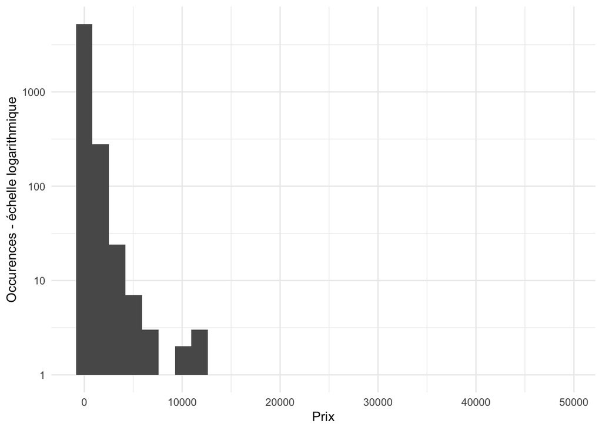

```r
df = data$find(fields = '{ "_id": 0, "price": 1 }')
ggplot(df, aes(price)) +
  geom_histogram() +
  scale_y_log10() +
  theme_minimal() +
  labs(x = "Prix", y = "Occurences - échelle logarithmique")
```

### Croiser numériquement et graphiquement le type et le prix (price)

```r
data$aggregate(
'[
  { "$group": { "_id": "$room_type", "prix_moyen": { "$avg": "$price" }}}
]')
```

```
##               _id prix_moyen
## 1    Private room   212.2965
## 2     Shared room   349.5904
## 3 Entire home/apt   314.8598
```

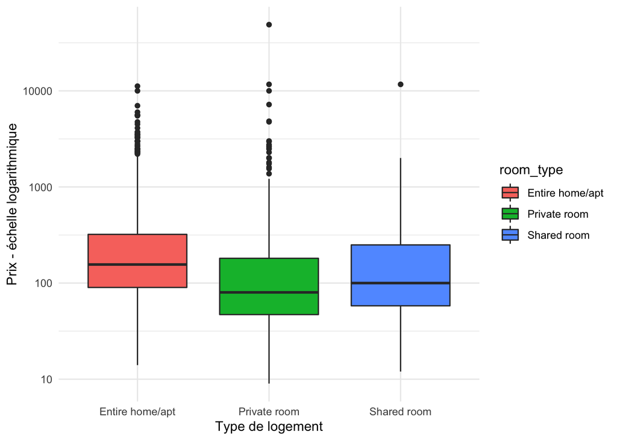

```r
df = data$find(fields = '{ "_id": 0, "price": 1, "room_type": 1 }')
ggplot(df, aes(room_type, price, fill = room_type)) +
  geom_boxplot() +
  scale_y_log10() +
  theme_minimal() +
  labs(x = "Type de logement", y = "Prix - échelle logarithmique")
```

### Représenter la distribution du nombre d’avis

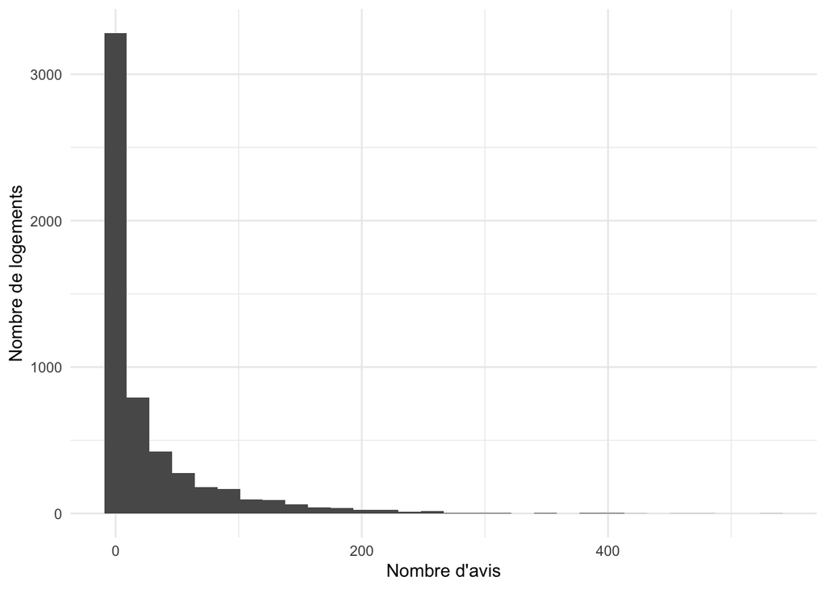

```r
df = data$aggregate(
'[
  { "$project": { "nb_avis": { "$size": "$reviews" }}}
]'
)
ggplot(df, aes(nb_avis)) +
  geom_histogram() +
  theme_minimal() +
  labs(x = "Nombre d'avis", y = "Nombre de logements")
```

### Croiser graphiquement le nombre d’avis et le prix, en ajoutant l’information du type de logement

On peut le faire avec toutes les données (nuage de points).

- *Problème* : on doit récupérer dans R toutes les données, ce qui peut ne pas être possible en cas de **big data**.
- *Avantage* : on peut avoir une idée de la (non) corrélation entre les deux

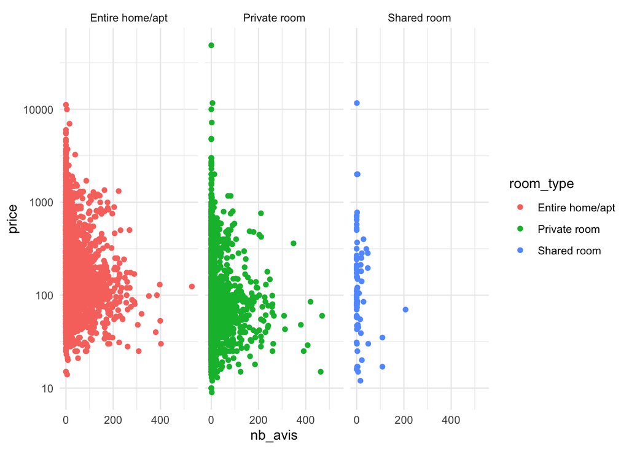

```r
df = data$aggregate(
'[
  { "$project": { "price": 1, "room_type": 1, "nb_avis": { "$size": "$reviews" }}}
]'
)
ggplot(df, aes(nb_avis, price, color = room_type)) +
  geom_point() +
  scale_y_log10() +
  facet_wrap(~ room_type) +
  theme_minimal()
```

#### Autre possibilité

On demande un calcul statistique à Mongo, qu’on représente graphiquement dans R. Dans ce cas, nous réalisons les étapes suivantes :

1. Ajout du nombre d’avis
2. Discrétisation de cette variable en une variable ordinale à l’aide de [`$bucket`](https://docs.mongodb.com/manual/reference/operator/aggregation/bucket/),
- avec les intervalles suivants :
  - $= 0$
  - $= 1$
  - $\in [2;4]$
  - $\in [5;9]$
  - $\in [10;99]$
  - $\ge 100$
- cet opérateur fait 2 opérations :
  - modification d’un champs (donné dans `groupBy`) en variable ordinale, basée sur les limites passés dans `boundaries`
  - calcul d’agrégats dans `output`, de la même façon que dans `$group`
3. Déroulement du tableau `infos`, pour chaque modalité de `nb_avis`
- ce tableau contient, pour chaque logement, le type et le prix
4. Calcul d’agrégats par type de logement et par tranche du nombre d’avis
5. Projection pour une utilisation plus simple dans R

```r
df = data$aggregate(
  '[
  { "$addFields": { "nb_avis": { "$size": "$reviews" }}},
  { "$bucket": {
  "groupBy": "$nb_avis",
  "boundaries": [ 0, 1, 2, 5, 10, 100, 1000],
  "output": {
    "infos": { "$push": { "type": "$room_type", "prix": "$price" }}
  }
  }},
  { "$unwind": "$infos" },
  { "$group": {
    "_id": { "type": "$infos.type", "avis": "$_id" },
    "nbLogements": { "$sum": 1 },
    "prixMoyen": { "$avg": "$infos.prix" },
    "prixET": { "$stdDevPop": "$infos.prix" }
  }},
  { "$project": {
    "_id": 0,
    "type": "$_id.type",
    "avis": "$_id.avis",
    "nb": "$nbLogements",
    "prix": "$prixMoyen",
    "prix_sd": "$prixET"
  }}
  ]'
)
df
```

```
##               type avis   nb       prix    prix_sd
## 1     Private room    2  253  184.48221  484.37581
## 2  Entire home/apt  100  317  202.00946  237.54689
## 3      Shared room    1   11 1302.63636 3327.97343
## 4      Shared room    2   13  316.07692  525.64897
## 5     Private room  100  128   99.07812  107.14532
## 6      Shared room  100    3   40.66667   22.00505
## 7  Entire home/apt    2  450  333.24889  569.63661
## 8      Shared room    5    5   81.00000   85.86734
## 9     Private room    1  179  162.00559  183.80809
## 10 Entire home/apt    5  334  303.60778  383.04145
## 11 Entire home/apt   10 1283  234.77864  332.74415
## 12     Shared room    0   35  212.68571  198.28058
## 13 Entire home/apt    0  831  460.02286  784.90216
## 14     Shared room   10   16  162.93750  116.52225
## 15    Private room    0  766  292.02611 1841.71471
## 16    Private room    5  131  247.08397 1016.99253
## 17    Private room   10  526  145.56844  184.91665
## 18 Entire home/apt    1  274  363.65693  472.61460
```

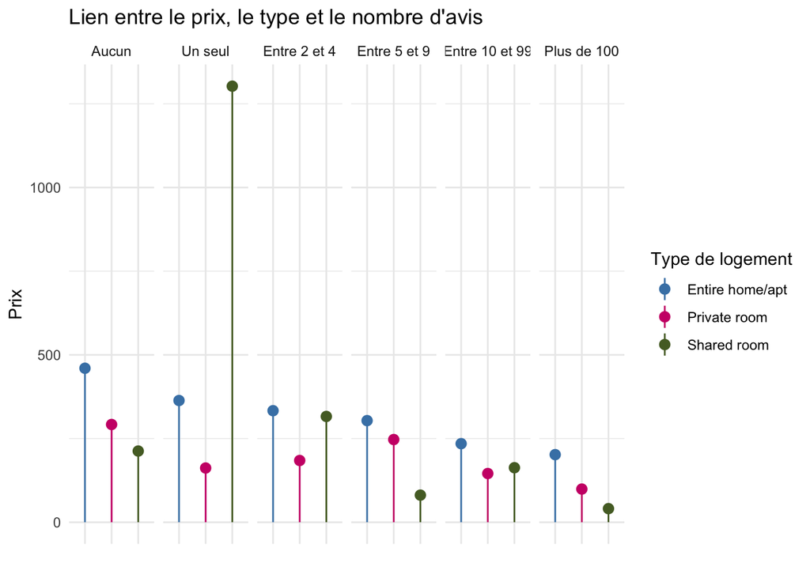

```r
modalites = c("Aucun", "Un seul", "Entre 2 et 4", "Entre 5 et 9", "Entre 10 et 99", "Plus de 100")
couleurs = c("steelblue", "deeppink3", "darkolivegreen")
ggplot(df, aes(x = type, y = prix, ymin = 0, ymax = prix, color = type)) +
  geom_pointrange() +
  scale_color_manual(values = couleurs) +
  facet_grid(~ factor(avis, labels = modalites)) +
  theme_minimal() +
  labs(x = "", color = "Type de logement", y = "Prix") +
  theme(axis.text.x = element_blank()) +
  ggtitle("Lien entre le prix, le type et le nombre d'avis")
```